title: “WasteWater Analysis 2.0” author: “Steve Goldstein and Marlin Lee” date: “7/13/2021” output: html_document

To give some measure of the variation of the data we look at the high frequency data. It shows that outliers often clump with the other filter replicates

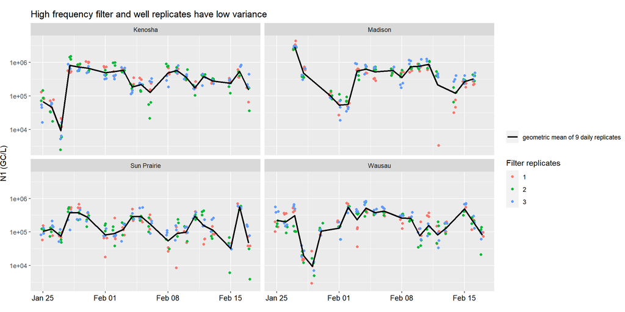

```r
N1PlotGraphic <- ggplot()+
  geom_jitter(aes(x=Date,y=N1,color=`Filter replicates`),width=.2,data=LimitedHFData)+
  geom_line(aes(x=Date,y=N1,linetype ="geometric mean of 9 daily replicates"),
            size=1,data=meanOfN1)+
  facet_wrap(~Site)+
  scale_y_log10()
```

PMMoV and percent bovine coronavirus recovery use is unclear. Unusual PMMoV and percent BCoV do not seem to relate to unusual N1 values.

```r
PMMoVUseDF=LimitedHFData%>%
  mutate(`PMMoV Level`=ifelse(PMMoV<1*10^7,"Low","Medium"))%>%
  mutate(`PMMoV Level`=ifelse(PMMoV>1*10^8,"High",`PMMoV Level`))%>%
  mutate(`PMMoV Level`=factor(`PMMoV Level`,levels=c("High","Medium","Low")))
```

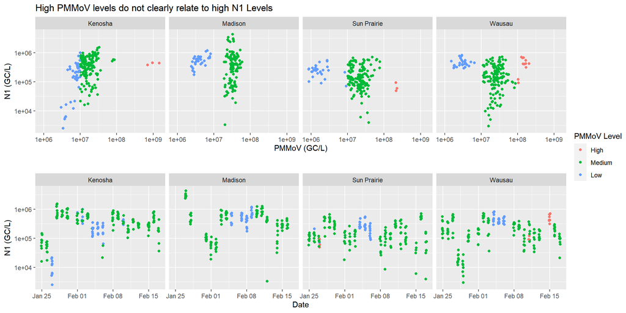

```r
BCoVUseDF=LimitedHFData%>%
  filter(N1<2e6)%>%
  mutate(`% BCoV Rec`=ifelse(Pct_BCoV<.5,"Low","Medium"))%>%
  mutate(`% BCoV Rec`=ifelse(Pct_BCoV>10,"High",`% BCoV Rec`))%>%
  mutate(`% BCoV Rec`=factor(`% BCoV Rec`,levels=c("High","Medium","Low")))
```

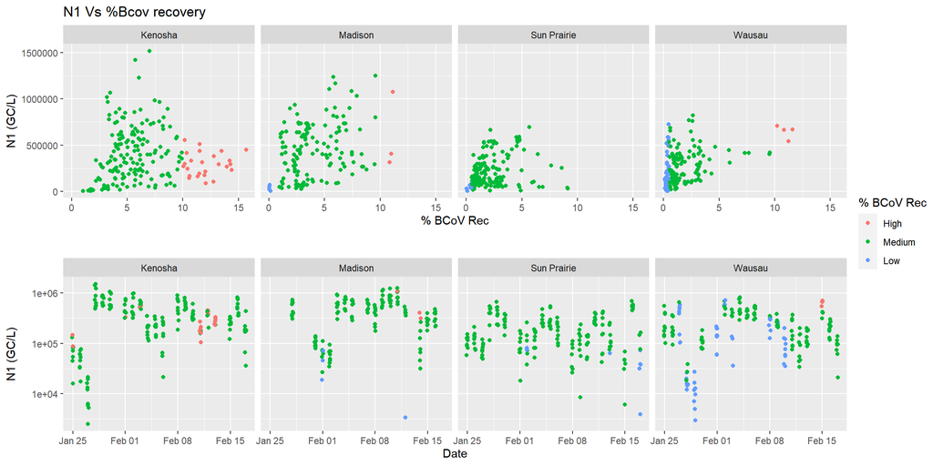

Due to the large daily variation of the N1 concentration we have tried to create a smoothed version of the data set that captures the N1 concentration. Below is our best attempt at smoothing. N2 shows a similar patern.

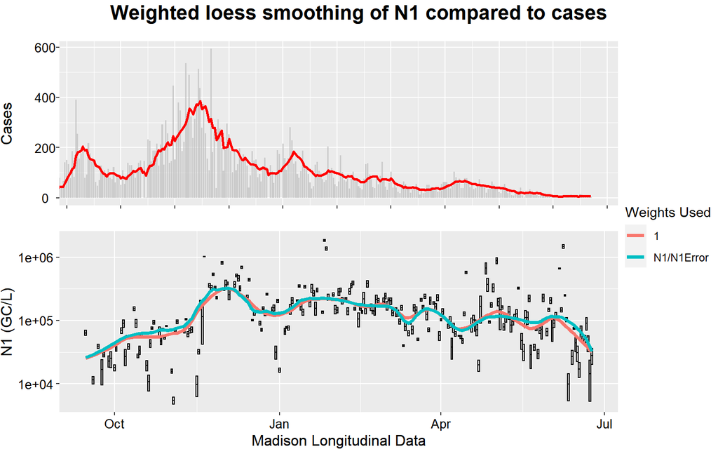

```r
N1Plot <- LoessSmoothPlot(SiteS="Madison",Span=.1,min=0,max=120,weights=c("Constant","N/NSE"),
                          Title = F,FullLim=F,SiteLab=F)

CasePlot <- CasePlotMaking("Madison")
```

To use standard error in our smoothing we need an error estimate independent of the concentration. SE/N1 is an effective weighting factor.

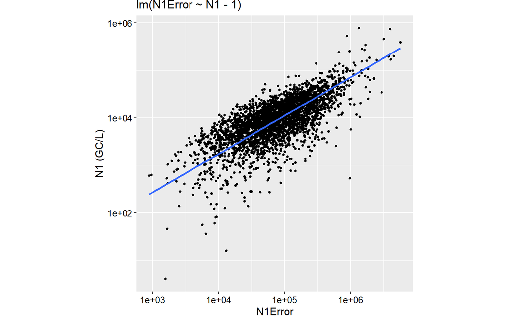

```r
N1ErrorN1Plot <- SimpleNErrorNModel(Independent="N1",Dependent="N1Error")
```

Below are the two versions of the smoothed data capturing different scales of its variations. The boxes are the concentration measured plus or minus the standard error. This gives some measure of how weighted the point is.

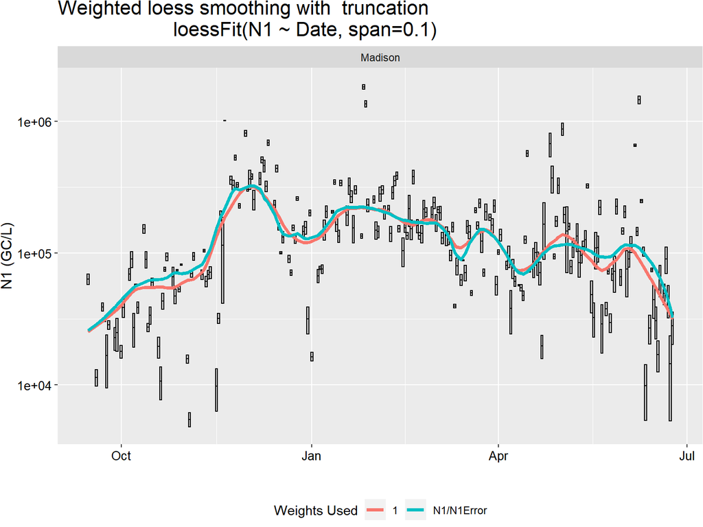

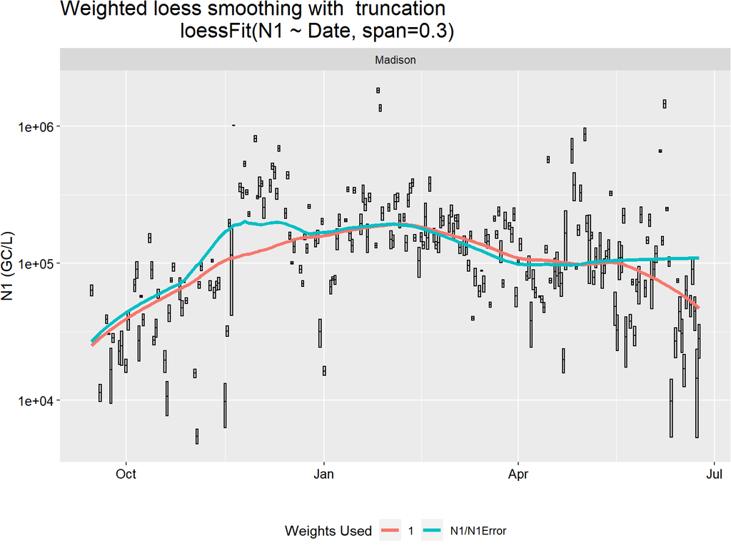

```r
LowSpanPlot <- LoessSmoothPlot(SiteS="Madison",Span=.1, weights=c("Constant","N/NSE"),
                               min=0,max=120)

HighSpanPlot <- LoessSmoothPlot(SiteS="Madison",Span=.3, weights=c("Constant","N/NSE"),
                                min=0,max=120)
```

Analysis of loess residuals suggest in progress data cleaning

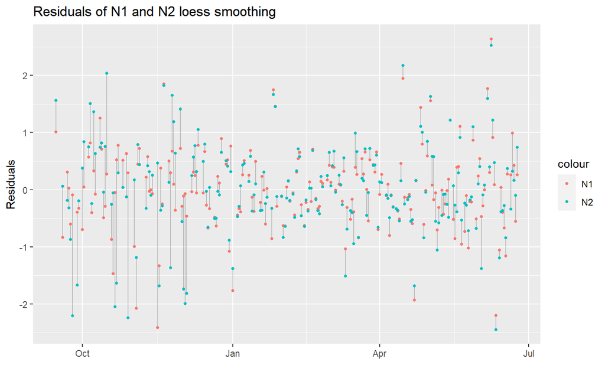

```r
MadLIMS%>%
  ggplot(aes(x=Date))+
  geom_segment(aes(y=ResidN1,yend=ResidN2,xend=Date),alpha=.2)+
  geom_point(aes(y=(ResidN1),color="N1"),size=1)+
  geom_point(aes(y=(ResidN2),color="N2"),size=1)+
  labs(title="Residuals of N1 and N2 loess smoothing",
       x="",y="Residuals")
```

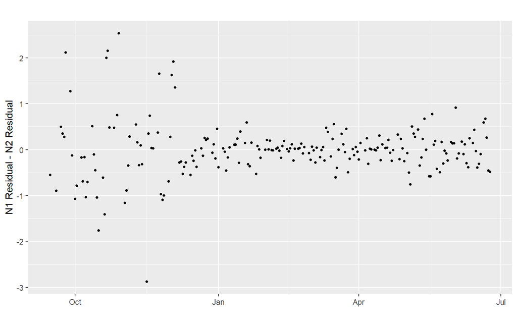

```r
MadLIMS%>%
  ggplot(aes(x=Date))+
  geom_point(aes(y=(ResidN1)-(ResidN2)),size=1)+
  labs(title="",
       x="",y="N1 Residual - N2 Residual")
```

This weighted smoothing is also applied to the UW data

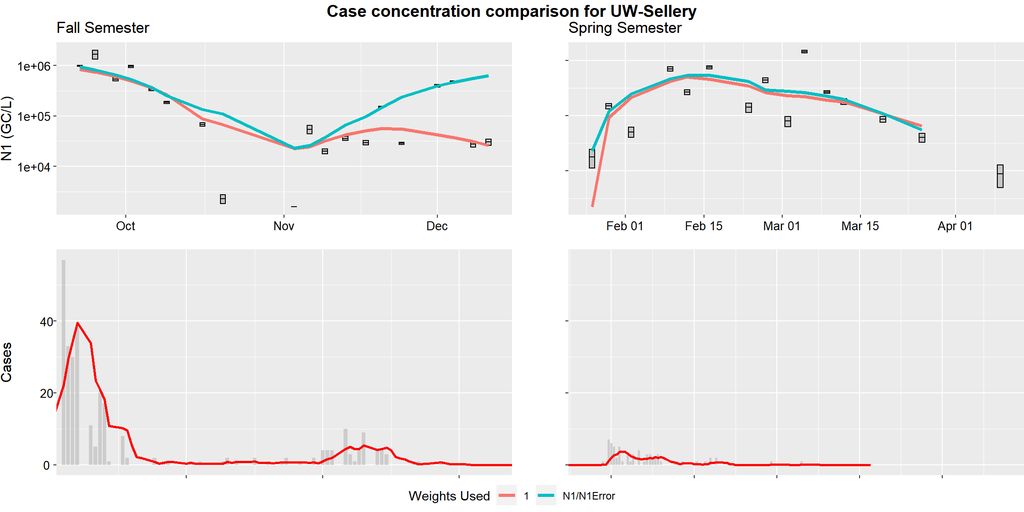

```r
N1CaseCompDorms(SiteS="UW-Sellery",Span=.5,Max=25,Weights=c("Constant","N/NSE"))
```

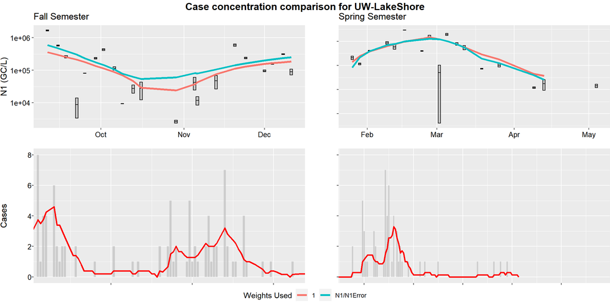

```r
N1CaseCompDorms(SiteS="UW-LakeShore",Span=.5,Max=25,Weights=c("Constant","N/NSE"))
```